# Guide Moulinette EvNat 094

[figure not shown]

# Moulinette EvNat 094

Analyser les évaluations nationales CP → CM2 d’une circonscription, ou de tout le département, à partir des exports REPERE, sans passer par le classeur Excel.

Téléchargement, guides et nouveautés : **mission-numerique-94.web.app**

## 1. À quoi sert la Moulinette

Chaque automne, l’IEN télécharge sur la plateforme REPERE le « rapport IEN » de sa circonscription : un fichier Excel avec, pour chaque école et chaque compétence, le nombre d’élèves du groupe à besoins, du groupe fragile et du groupe satisfaisant. Jusqu’ici, il fallait coller ce fichier à la main dans un classeur d’analyse, onglet par onglet, nettoyer les noms d’écoles, puis imprimer des graphiques qui se coupaient entre deux pages.

La Moulinette fait ce travail en quelques clics :

- elle lit directement l’export REPERE (brut ou déjà filtré) ;
- elle reconnaît les écoles, écarte d’office les maternelles et les lignes sans élève, et vous laisse régler le reste (privé, REP, réseaux, collèges, IPS) ;
- elle calcule juste : tous les pourcentages sont recalculés sur les élèves répondants, les moyennes de réseau ou de collège sont pondérées par les effectifs ;
- elle produit les mêmes graphiques que le classeur, lisibles, et les imprime en PDF sans jamais couper un graphique ou un tableau ;
- elle compare, si vous le souhaitez, avec l’année précédente (suivi de cohorte) ;
- elle sait ressortir les fichiers Excel habituels pour ceux qui y tiennent ;
- elle prépare un dossier complet de ses résultats à confier à l’Assistant IA de l’État, pour lui poser des questions en langage courant ;
- elle connaît les écoles du Val-de-Marne (annuaire officiel du ministère) : statut REP ou REP+, secteur, commune, circonscription et indice de position sociale sont pré-remplis ;
- elle sait aussi réunir plusieurs circonscriptions dans un même projet pour une lecture départementale et une comparaison des circonscriptions entre elles.

Deux années sont toujours nommées en clair : l’année en cours (par exemple les évaluations de septembre 2026, année scolaire 2026-2027) et l’année précédente (septembre 2025, année 2025-2026).

## 2. Installation

La Moulinette se télécharge sur **mission-numerique-94.web.app**, pour Mac, pour Windows et pour Linux, avec ce guide en PDF et la liste des nouveautés. Une fois installée, elle se met à jour toute seule : quand une nouvelle version est prête, un bandeau propose de l’installer.

**Sur Mac** : ouvrir le fichier `Moulinette EvNat 094-<version>-mac-arm64.dmg` (puce Apple M1, M2, M3…) ou `…-mac-x64.dmg` (Mac Intel) et glisser l’application dans le dossier Applications ; macOS 11 (Big Sur) ou plus récent. Au premier lancement, faire **clic droit → Ouvrir** (l’application n’est pas signée par Apple), puis confirmer. Si macOS répond « endommagé » ou « non compatible », ouvrir le Terminal et taper `xattr -dr com.apple.quarantine "/Applications/Moulinette EvNat 094.app"`, puis relancer.

**Sur Windows** : lancer `Moulinette EvNat 094-<version>-win-x64.exe`. Si SmartScreen s’affiche, cliquer sur « Informations complémentaires » puis « Exécuter quand même ». L’installation se fait en un clic.

**Sur Linux** : télécharger `Moulinette EvNat 094-<version>-linux-x64.AppImage`, le rendre exécutable (clic droit → Propriétés → « Autoriser l’exécution du fichier comme un programme », ou `chmod +x` dans un terminal), puis double-cliquer : rien ne s’installe, l’application s’ouvre depuis ce fichier. Le garder là où on l’a rangé : les mises à jour remplacent le fichier sur place et relancent l’application.

Le numéro de version est affiché en haut de la fenêtre ; en passant la souris dessus, on lit la date de la dernière mise à jour. Sous le titre de l’application, le lien « Vérifier les mises à jour » vérifie à la demande deux choses : l’application elle-même (« à jour » ou version disponible) et l’annuaire officiel des écoles (API data.education.gouv.fr : date de l’annuaire utilisé, ou annuaire plus récent disponible). Les deux vérifications se refont d’elles-mêmes toutes les dix minutes.

## 3. Le parcours en sept étapes

La colonne de gauche liste les sept étapes. Les étapes grisées se débloquent à mesure que le projet avance ; on peut revenir en arrière à tout moment.

### Étape 1 — Projet

[figure not shown]

Au premier lancement : on choisit le périmètre, on nomme la circonscription (ou le département), on vérifie l’année scolaire, puis « Créer et importer ».

**Enregistrement.** Dès « Créer et importer », l’application demande où enregistrer le fichier du projet. Ensuite, la case « Enregistrer automatiquement les modifications » (cochée par défaut, écran Projet) écrit chaque changement dans ce fichier quelques secondes après ; on peut la décocher pour n’enregistrer qu’à la main (menu Fichier → Enregistrer, ⌘S sur Mac ou Ctrl+S sur Windows et Linux). Chaque enregistrement manuel est confirmé par un petit message en bas de la fenêtre.

[figure not shown]

Projet en cours : état des étapes, enregistrement, renseignements modifiables.

### Étape 2 — Importer

[figure not shown]

Déposer le fichier REPERE dans la zone de gauche, ou cliquer pour le choisir.

Le fichier attendu est le « rapport IEN » téléchargé sur REPERE (`Suivi_IEN_….xls` en 2025, `Suivi_IEN_….xlsx` en 2026). Le fichier brut convient tel quel ; un fichier déjà filtré à la main convient aussi. REPERE a changé le nom de ses onglets en 2026 (« CPF », « CPM », « CE1F »… au lieu de « CPFR », « CPMA »…) : les deux présentations sont reconnues, et l’année des évaluations est lue dans le fichier.

Une fois le fichier lu, la Moulinette affiche ce qu’elle a compris : la circonscription, les dix niveaux avec leur nombre de compétences, les établissements par type et secteur, et les préréglages appliqués.

[figure not shown]

Diagnostic après lecture : 29 établissements reconnus, 13 sans élève évalué exclus d’office, aucune anomalie.

> **Si le fichier n’est pas reconnu**, le message l’indique clairement. La lecture ne repose pas sur des positions de cellules fixes mais sur les intitulés du fichier (« Compétence », « Groupe à besoins », « Nombre »…) : une nouvelle mise en page de REPERE a de bonnes chances de passer, mais prévenez-nous si ce n’est pas le cas.

#### Importer l’année précédente

La zone de droite, « Année précédente », sert au suivi de cohorte : on y dépose le fichier de **l’année précédente**, au choix l’export REPERE de l’an dernier ou le classeur Excel « Analyse EvNat » rempli l’an dernier (version 2025 ou 2026). Ce n’est pas obligatoire : sans année précédente, tout le reste fonctionne. Dès que les deux années sont présentes (après l’import, ou à l’ouverture d’un projet), les écoles sont appariées automatiquement, par leur UAI. Le bouton sous le fichier est bleu « Vérifier l’appariement (n à confirmer) » quand des rapprochements restent incertains ; sinon il est blanc, « Appariement fait : le revoir ».

[figure not shown]

Les deux années importées : à droite, le classeur Excel rempli l’an dernier.

### Étape 3 — Écoles

C’est l’étape où l’on vérifie et où l’on règle. Chaque ligne est un établissement présent dans REPERE.

[figure not shown]

Juste après l’import : les écoles élémentaires et primaires sont cochées, les maternelles décochées, les noms raccourcis.

#### REP, hors REP : d’où vient l’information

Le fichier REPERE ne dit pas si une école est en éducation prioritaire. La Moulinette pré-remplit la colonne REP depuis l’annuaire officiel des écoles du Val-de-Marne (data.education.gouv.fr) : OUI pour les écoles REP et REP+ (un badge signale les REP+), NON pour les autres. Le statut reste modifiable école par école. Si une école n’est pas trouvée dans l’annuaire, la colonne affiche « ? » : elle n’entre alors ni dans la moyenne REP ni dans la moyenne hors REP, et le bouton « Hors REP si “ ? ” » permet de la classer hors REP d’un coup. Le même annuaire fournit, quand il existe, l’indice de position sociale (IPS) de l’école.

#### Retenir ou écarter des écoles

Ce qui est fait d’office, comme le faisait le filtrage manuel :

- maternelles, IME, lignes techniques de REPERE et écoles sans aucun élève évalué sont **décochées** ;
- les écoles **privées restent cochées** ; le bouton « Retirer le privé » les écarte d’un coup si l’IEN le souhaite, « Garder le privé » les remet ;
- le **nom affiché** est raccourci automatiquement (« ECOLE ELEMENTAIRE PUBLIQUE CENTRE - ST MAUR DES FOSSES » devient « Centre ») et reste modifiable : c’est ce nom qui apparaît sur tous les graphiques.

#### Renseigner REP, réseaux, collèges et IPS

Ce que l’on renseigne soi-même, selon les besoins :

- **REP** : OUI ou NON, pour obtenir les moyennes REP et hors REP ;
- **Réseau** et **Collège** : un nom libre (« Réseau Rabelais », « Ronsard »…) ; la liste se complète au fil de la saisie, il suffit de choisir le même nom pour les écoles d’un même réseau. Aucune donnée publique ne fournit ces rattachements : le bouton « Mémoriser réseaux et collèges » les conserve sur votre ordinateur (et enregistre le projet en même temps), et ils sont pré-remplis dans les projets suivants pour les mêmes écoles ;
- **IPS** : l’indice de position sociale de l’école, pour les nuages de points.

[figure not shown]

Après réglage : REP, réseaux, collèges et IPS renseignés.

La colonne « Niveaux évalués » est déduite des données : une école qui n’a pas de CM2 n’en aura pas. La liste déroulante en haut à droite permet de n’afficher que les écoles retenues ou exclues.

Quand une année précédente est rattachée, un sélecteur d’année apparaît en haut de l’écran : on peut y régler les REP, réseaux, collèges et IPS propres à l’année précédente (ceux de l’époque). Ils ne comptent que si l’on choisit, dans Cohorte, de comparer chaque année avec ses propres réglages ; par défaut, les réglages de l’année en cours s’appliquent aux deux années.

[figure not shown]

Écoles, année précédente : les réglages de l’époque, utilisés seulement si Cohorte compare chaque année avec ses propres réglages.

### Étape 4 — Résultats

Huit vues (neuf pour un projet départemental), présentées en onglets au-dessus du graphique (Par compétence, Radar, Camemberts, Tableau de chaleur, Vue d’ensemble, Réseaux et collèges, Évolution CP → CM2, Position IPS), un sélecteur de niveau, et deux entités à comparer. Une « entité » peut être une école, la circonscription, la moyenne REP ou hors REP, un réseau, un collège, le département ou le national. Quand l’année précédente est importée, les deux listes proposent aussi, en fin de liste et marquées « [N-1] », les entités de l’année précédente au même niveau ; chaque entité affiche alors son année, « Jules Ferry (2026-2027) » face à « [N-1] Jules Ferry (2025-2026) », dans les listes comme dans les légendes, les titres et les tableaux des graphiques (moyennes REP et hors REP comprises) : on compare ainsi les CP de 2026 aux CP de 2025 d’une même école, de la circonscription, du REP ou d’un réseau, pour tous les niveaux et dans toutes les vues (barres, radar, camemberts, vue d’ensemble, évolution), ainsi que comme référence à l’impression. Les compétences des deux années sont rapprochées par leur intitulé, sinon par la notion mesurée ; une compétence nouvelle cette année reste vide pour l’an dernier. Ce n’est pas un suivi de cohorte (ce ne sont pas les mêmes élèves) : c’est la comparaison d’une promotion à la précédente. L’entité B peut aussi être « Aucune référence » : le graphique ne montre alors que l’entité A, sans seuils ni écarts. Dans toutes les listes, les ensembles (circonscription, moyennes REP et hors REP, réseaux, collèges, département) viennent en tête, précédés d’un tiret, puis les écoles.

[figure not shown]

Par compétence : les barres de l’entité A (ici Centre), les triangles de l’entité B (la circonscription) : noir « à besoins », rouge « à besoins + fragiles ».

#### Lire le graphique à triangles

Chaque barre montre, pour une compétence, la part d’élèves à besoins (bleu), fragiles (orange) et satisfaisants (vert) de l’entité A. Les triangles marquent les seuils de l’entité B : le triangle noir à la hauteur de ses élèves à besoins, le triangle rouge à la hauteur de ses élèves à besoins + fragiles. Quand la barre orange de l’école reste sous le triangle rouge, l’école compte moins d’élèves en difficulté que la circonscription sur cette compétence. Il n’y a volontairement pas de ligne entre les triangles : chaque compétence se lit pour elle-même. Forme, couleur et taille des symboles se règlent dans Apparence.

Sous le graphique, le tableau récapitulatif reprend les chiffres, compétence par compétence : à besoins, fragiles, puis fragiles + à besoins, pour A et pour B ; les satisfaisants de A (A) et de B (B) ; l’**écart A − B des satisfaisants** ; le nombre de répondants. Une légende sous le tableau rappelle les couleurs :

- **Vert** : pourcentage d’élèves le plus faible de la colonne, parmi les compétences évaluées.
- **Rouge** : pourcentage d’élèves le plus élevé de la colonne, parmi les compétences évaluées.
- **Jaune** : écart A − B négatif (A en dessous de B pour les élèves « Satisfaisants ») ; la compétence est alors surlignée en jaune elle aussi. Un écart positif reste en blanc.

En survolant une cellule, une infobulle en donne le sens et les effectifs.

**Imprimer un seul graphique ou un seul tableau.** Dans Résultats et Cohorte, chaque graphique et chaque tableau a un petit bouton « PDF » juste au-dessus, à droite, qui ne recouvre rien : une fenêtre propose un titre, l’orientation (paysage ou portrait) et la taille (toute la page ou demi-page) ; « Aperçu » montre la page dans une petite fenêtre à part, que l’on ferme d’un clic, et « Enregistrer le PDF… » enregistre ce seul élément, avec l’en-tête et le pied de page des dossiers. Pour un dossier complet, on passe par l’écran Imprimer.

**Imprimer toute la vue d’un coup.** Dès qu’une vue affiche au moins deux graphiques ou tableaux, par exemple l’évolution du CP au CM2, un bouton « Toute la vue en PDF » apparaît en haut à droite de l’écran, avec le nombre d’éléments. Sa fenêtre propose un titre pour la première page, l’orientation, et 1, 2 ou 4 graphiques par page. La liste des éléments, dans l’ordre de l’écran, permet d’en décocher. Chaque tableau occupe sa propre page. « Aperçu » montre toutes les pages dans la petite fenêtre à part, et « Enregistrer le PDF… » fait un seul fichier.

[figure not shown]

Le bouton « Toute la vue en PDF » en haut à droite de la vue Évolution du CP au CM2.

[figure not shown]

Radar : une branche par compétence, la part d’élèves fragiles et à besoins de l’entité A (bleu) et de l’entité B (orange) ; plus la surface est petite, moins il y a d’élèves en difficulté.

[figure not shown]

Camemberts : pour un niveau, un camembert par compétence (à besoins, fragiles, satisfaisants), pour l’entité A puis pour l’entité B.

[figure not shown]

Tableau de chaleur : pour un niveau, chaque école sur une ligne, chaque compétence en colonne, la part d’élèves fragiles et à besoins colorée du vert au rouge ; les écoles sont triées de la plus fragile à la plus solide.

Le tableau de chaleur donne en un coup d’œil, pour la circonscription entière, les compétences et les écoles qui concentrent les difficultés. La première ligne est la référence (la circonscription). La pastille orange « ⚠ <10 » marque une école de moins de dix répondants (le nombre exact s’affiche au survol) : un seul élève y fait varier le pourcentage de plusieurs points, la lecture doit rester prudente.

[figure not shown]

Vue d’ensemble : la moyenne des élèves satisfaisants par niveau pour l’école, la circonscription, le REP et le hors REP, puis la synthèse pondérée.

[figure not shown]

Réseaux et collèges : part des élèves fragiles et à besoins, compétence par compétence, pour deux regroupements.

L’onglet « Évolution CP → CM2 » suit une même notion de niveau en niveau ; l’onglet « Position IPS » place chaque école selon son IPS. Dans Imprimer, ce sont les représentations « Évolution CP → CM2 des compétences suivies » (par sujet) et « Position des écoles selon l’IPS » (une fois pour le dossier).

[figure not shown]

Évolution CP → CM2 : une même notion suivie de niveau en niveau (compréhension orale, dictée, lecture à voix haute, nombres, droite graduée, problèmes).

[figure not shown]

Position IPS : chaque école placée selon son IPS et sa moyenne d’élèves satisfaisants ; le losange orange est la circonscription.

> **Deux moyennes, deux définitions.** La « moyenne école » est la moyenne simple des pourcentages de ses compétences, comme dans le classeur. Les moyennes de regroupement (REP, réseau, collège, circonscription) additionnent les effectifs des écoles avant de calculer le pourcentage : elles sont donc pondérées par la taille des écoles.

### Étape 5 — Cohorte

Si une année précédente a été importée, cette étape compare les mêmes élèves d’une année sur l’autre : CP → CE1, CE1 → CE2, CE2 → CM1, CM1 → CM2, en français et en maths.

[figure not shown]

Comparer : pour l’entité suivie, les élèves satisfaisants l’an dernier (bleu clair) et cette année (bleu), et pour la référence choisie (gris, puis orange), compétence par compétence ; le tableau donne les évolutions des deux et leur écart.

La liste « Comparer à » met en regard la même cohorte d’une autre entité : la circonscription (par défaut), le département, la moyenne REP ou hors REP, un réseau, un collège, une autre école, ou aucune comparaison. Le graphique montre alors quatre séries et le tableau ajoute l’évolution de la référence et l’écart des évolutions (une école qui progresse de 4 points quand la circonscription progresse de 1 fait mieux que la tendance). À l’impression, la référence choisie dans « 2. Comparer à » vaut aussi pour les cohortes.

#### Corriger les appariements

Deux appariements sont faits automatiquement et restent corrigeables :

[figure not shown]

Écoles appariées : par UAI quand les deux fichiers en ont un, sinon par le nom. Une proposition à confirmer est signalée en jaune.

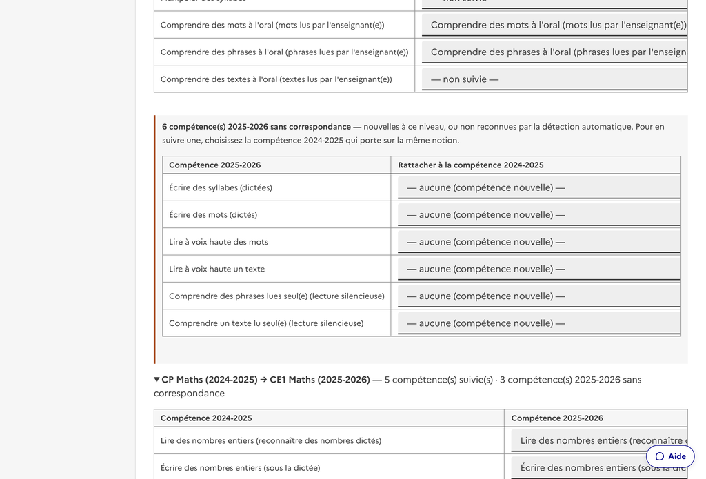

Compétences appariées : pour chaque passage de niveau, la compétence de l’an dernier est rapprochée de celle de cette année qui porte sur la même notion.

Pourquoi certaines compétences de cette année n’apparaissent-elles pas dans la colonne de droite ? Chaque ligne du tableau part d’une compétence de l’an dernier : la colonne de droite n’affiche que la compétence de cette année qu’on lui a associée. Or d’un niveau à l’autre, REPERE n’évalue pas les mêmes choses. En CP, on évalue par exemple les phonèmes ou le nom des lettres ; en CE1, la lecture à voix haute ou l’écriture de syllabes dictées. Ces compétences nouvelles n’ont pas d’équivalent l’an dernier, et la détection automatique, volontairement prudente, ne les rattache à rien plutôt que de comparer deux notions différentes.

Rien n’est caché pour autant :

- **Chaque liste de droite propose toutes les compétences de cette année.** Celles déjà associées à une autre ligne portent la mention « déjà associée ».
- **Sous chaque tableau, un encadré liste les compétences de cette année sans correspondance.** Pour en suivre une, choisissez la compétence de l’an dernier qui porte sur la même notion ; si cette compétence était déjà associée à autre chose, la liste l’indique (« remplace : … »).
- **Le titre de chaque passage de niveau** indique le nombre de compétences suivies et le nombre de compétences de cette année restées sans correspondance.

> Le classeur Excel ne suivait qu’une école à la fois, celle sélectionnée dans chacun des deux fichiers. Ici, toutes les écoles sont appariées d’un coup et l’on peut aussi suivre un réseau, un collège ou la circonscription.

#### Si les REP, réseaux ou collèges ont changé entre les deux années

Une école peut entrer en REP ou en sortir, un réseau peut être recomposé d’une année sur l’autre. Deux lectures sont possibles, au choix en haut de l’écran Cohorte :

- **À périmètre constant** (par défaut) : les réglages de l’année en cours (REP, réseaux, collèges, IPS) sont appliqués aux deux années. On compare les mêmes groupes d’écoles, ce qui isole l’évolution des résultats de celle des étiquettes. C’est la lecture recommandée pour « la moyenne REP a-t-elle progressé ? ».
- **Chaque année avec ses propres réglages** : l’année précédente garde ses REP, réseaux, collèges et IPS de l’époque, tels qu’ils sont renseignés dans Écoles pour cette année (sélecteur d’année). On compare alors le REP d’alors au REP d’aujourd’hui, avec des groupes d’écoles qui peuvent différer. À réserver aux cas où l’on veut précisément mesurer l’effet d’un changement de carte.

Dans les deux cas, l’inclusion des écoles et leurs noms affichés suivent l’année en cours pour les écoles appariées, et les résultats de chaque école ne bougent jamais.

[figure not shown]

Cohorte : le choix du périmètre, puis la comparaison.

### Étape 6 — Imprimer

On compose le dossier en quatre choix, on regarde l’aperçu (une roue tourne pendant sa construction ; il s’affiche dans une zone qui défile pour elle-même, la page restant accessible à côté), on exporte en PDF, ou un PDF par sujet.

[figure not shown]

Composer : les modèles en haut, puis « Pour qui ? », « Comparer à », « Quoi ? » et la mise en page ; l’aperçu s’affiche en dessous.

#### Composer le dossier

- **Modèles** : un clic règle tout pour les demandes courantes (dossier d’une école, toutes les écoles, la circonscription, un réseau REP, REP face au hors REP, comparer les circonscriptions) ; on ajuste ensuite si besoin.
- **1. Pour qui ?** On coche un ou plusieurs sujets : des écoles, des regroupements (REP, hors REP, réseaux, collèges), des circonscriptions (projet départemental), la circonscription ou le département. Un dossier est produit par sujet.
- **2. Comparer à** : la référence dont on trace les seuils et la courbe de comparaison, ou aucune. C’est là que se règlent les comparaisons : une école face à son réseau, un réseau face à la circonscription, une circonscription face au département.
- **3. Quoi ?** Les niveaux, puis les représentations : barres par compétence avec les seuils, radar, camemberts, tableaux récapitulatifs, vue d’ensemble, évolution CP → CM2, cohortes (par sujet) ; tableau de chaleur, regroupements face à face, comparaison des circonscriptions, position IPS (une seule fois pour le dossier). Les liens « toutes », « aucune » et « par défaut » (page de garde, barres, tableaux récapitulatifs) règlent les représentations d’un clic, comme « tous » et « aucun » pour les niveaux.
- **4. Mise en page et sortie** : A4 portrait ou paysage, un ou deux graphiques par page ; « Aperçu », « Exporter en PDF… » (un seul fichier) ou « Un PDF par sujet dans un dossier… » (un fichier par école, par réseau ou par circonscription, nommés d’après le sujet).

Chaque graphique ou tableau occupe une carte entière, dimensionnée pour la page : rien n’est jamais coupé. Un tableau trop long passe d’abord seul sur sa page, puis, s’il le faut, continue sur les pages suivantes avec ses titres de colonnes repris en grisé ; un tableau trop large abrège ses textes longs, autant qu’il le faut pour que plus rien ne soit coupé à droite, avec un renvoi numéroté, (1), (2)…, vers une note sous le tableau qui donne le texte complet ; en dernier recours, il réduit la taille des chiffres. Le PDF reprend exactement l’aperçu, avec le logo, la circonscription, l’année et le numéro de page.

[figure not shown]

Page de garde, avec l’aide à la lecture.

[figure not shown]

Une page de niveau : le graphique et son tableau récapitulatif.

[figure not shown]

### Étape 7 — Exporter

[figure not shown]

En tête, l’export pour poser des questions à l’IA ; en dessous, les trois autres sorties : l’export REPERE modifié, le classeur Analyse EvNat 2026 rempli, les données.

Le dossier pour l’IA couvre toujours toutes les années du projet. Pour les trois autres sorties, on choisit l’année à exporter : l’année en cours, l’année précédente (si elle est rattachée) ou les deux, auquel cas un fichier est produit par année. L’année précédente est exportée avec ses propres résultats ; ses écoles appariées héritent des réglages de l’année en cours.

- **Export pour poser des questions à l’IA** : un seul fichier texte, complet et commenté, à joindre à l’**Assistant IA de l’État** (assistant.numerique.gouv.fr, connexion ProConnect). Il contient les écoles et leurs réglages, les résultats détaillés de toutes les entités (écoles, circonscription, REP et hors REP, réseaux, collèges, et les circonscriptions du département le cas échéant), les synthèses par niveau, les écarts à la référence, la position IPS et, si l’année précédente est rattachée, le suivi de cohorte, avec les définitions nécessaires pour les interpréter. On lui pose ensuite ses questions en langage courant. Aucun nom d’élève ni d’enseignant.
- **Export REPERE modifié** : le rapport IEN au format « filtré », avec uniquement les écoles retenues et leurs noms affichés, plus un onglet Écoles (UAI, type, secteur, REP, réseau, collège, IPS).
- **Classeur « Analyse EvNat 2026 » rempli** : le classeur Excel de l’outil actuel, avec la liste des écoles, REP, réseaux, collèges, IPS et les résultats collés dans les dix onglets. Ses formules et ses graphiques sont conservés ; Excel recalcule à l’ouverture. Limite du gabarit : 25 écoles, 8 réseaux, 8 collèges.
- **Données** : un tableau CSV (une ligne par école, niveau et compétence) pour un tableur, ou le projet complet en JSON.

Les libellés de classe, qui contiennent parfois des noms d’enseignants, ne sont jamais exportés.

### Apparence des graphiques

Les couleurs se changent **sur les graphiques témoins de l’écran Apparence**, par un clic droit sur l’élément : une barre, un symbole de seuil, un point, une courbe, une part de camembert, une entrée de légende ou une cellule de tableau. Le menu montre la couleur de cet élément, avec un bouton pour revenir au préréglage en vigueur (l’élément réaffiché s’il était masqué, sa couleur, et pour un symbole de seuil aussi sa forme et sa taille), et rien d’autre ; il reste ouvert tant qu’on règle. Sur un symbole de seuil, il propose aussi sa forme (triangle, rond, carré, losange, étoile, croix) et sa taille. La case cochée devant la couleur affiche l’élément : la décocher le masque sur tous les graphiques (son nom est alors barré dans la légende), la recocher le ramène. Dans les écrans de résultats, les graphiques se lisent et ne se modifient pas ; un clic sur une légende n’y masque rien non plus. Le changement s’applique aussitôt à tout le projet, écrans et PDF.

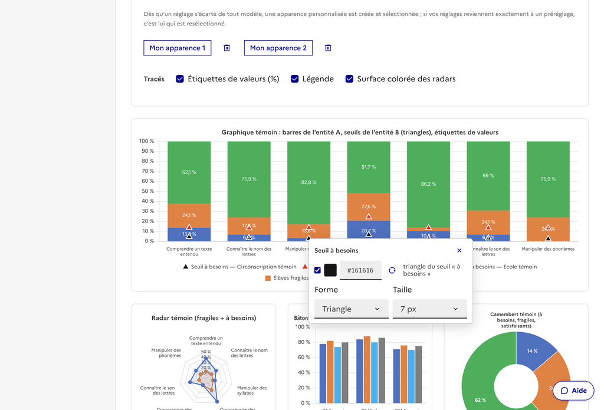

Clic droit sur un symbole de seuil : la case qui l’affiche ou le masque, sa couleur, sa forme, sa taille.

L’entrée « Apparence », sous les sept étapes, rassemble le reste :

[figure not shown]

Apparence : l’encadré du clic droit, les préréglages (le modèle en vigueur en couleur pleine), les apparences personnalisées et les tracés, puis les graphiques témoins (barres, radar, bâtons, camembert, évolution, IPS) et le tableau témoin.

- **Préréglages**, en premier : celui du classeur Excel (par défaut : ce sont les couleurs que les circonscriptions utilisent aujourd’hui), les couleurs de l’État (DSFR, la charte officielle de l’administration, pour un dossier transmis à la DSDEN ou au rectorat), une palette lisible par les personnes daltoniennes (Okabe-Ito, pour un document largement diffusé), des gris pour l’impression en noir et blanc. Chaque préréglage règle aussi les couleurs des tableaux (minimum, maximum, alerte, échelle de chaleur) dans sa propre logique : jetons officiels succès / erreur / jaune tournesol pour DSFR, teintes Okabe-Ito pour le daltonisme, gris pour le noir et blanc. Les symboles de seuil suivent la même logique partout, le noir pour « à besoins », le rouge de la palette pour « à besoins + fragiles » (blanc dans les gris), et portent un fin liseré contrasté pour rester lisibles sur toute barre, y compris le bleu France. Le modèle en vigueur est en couleur pleine ; survoler un bouton rappelle quand l’utiliser.
- **Mes apparences** : il n’y a rien à enregistrer. Dès qu’un réglage s’écarte de tout modèle (une couleur, un symbole, un tracé, un élément masqué), une apparence personnalisée est créée sur votre ordinateur, sélectionnée, et son nom se modifie dans le champ qui apparaît ; un petit message en bas de la fenêtre confirme chaque enregistrement. Elle suit vos modifications. Si vos réglages reviennent exactement à un préréglage, c’est lui qui est resélectionné et l’apparence devenue identique disparaît. Les apparences personnalisées sont proposées pour tous les projets et se suppriment d’un clic.
- **Tracés**, dans la même carte : étiquettes de valeurs, légende, surface des radars. Les symboles de seuil se masquent par leur case dans le menu du clic droit. Il n’y a pas de ligne entre les seuils : elle relierait des compétences sans lien entre elles, seul compte le symbole face à la barre de la même compétence.
- **Graphiques témoins** (barres à seuils, radar, bâtons, camembert, évolution CP → CM2, position IPS), faits de données fictives qui montrent chaque élément réglable : on y fait son clic droit sans avoir besoin d’un projet rempli.
- **Tableau témoin** : valeurs minimale et maximale, alerte, échelle de chaleur, chacune par clic droit sur la cellule.

Le réglage est enregistré avec le projet. Pour imprimer un dossier avec une autre apparence, on règle, on exporte, puis on revient à la palette précédente d’un clic.

### L’aide intégrée

Le bouton « Aide », en bas à droite (ou ⌘ J / Ctrl J), ouvre un volet discret qui sait dans quelle section vous êtes : l’écran, la vue, le niveau affiché. Elle répond en local, sans rien envoyer sur internet, à partir du présent guide.

[figure not shown]

- **Elle répond aux questions d’usage** : « comment lire le graphique à triangles ? », « comment obtenir un PDF par école ? », « d’où vient le statut REP ? ». Elle cite la section du guide qui répond, avec sa capture d’écran ; « Voir » ouvre le guide à cet endroit.
- **Elle propose des questions** adaptées à la section où vous êtes (trois questions techniques), qui changent d’écran en écran et de vue en vue.
- **Les chiffres, c’est son grand frère** : la quatrième question, toujours présente, « Poser une question statistique », comme toute question chiffrée (compétences fragiles, écarts entre écoles, effectifs…), renvoie vers l’**Assistant IA de l’État** (assistant.numerique.gouv.fr, connexion ProConnect avec vos identifiants académiques). La bulle propose « Enregistrer le dossier pour l’IA » (le fichier complet décrit à l’étape Exporter), « Ouvrir l’Assistant IA » et « Copier la question ». Le dossier ne contient aucun nom d’élève ; ce que vous transmettez à un service en ligne reste sous votre responsabilité.
- **Elle dit quand elle ne sait pas** : une question qui ne trouve pas de section dans le guide reçoit la même proposition de passage de main, plutôt qu’une réponse inventée.
- **Réinitialiser** : le bouton de réinitialisation, en haut du volet, vide la conversation et repart de l’accueil.
- **Ce qu’elle est** : une aide locale par mots-clés, pas un modèle d’intelligence artificielle embarqué. Elle n’occupe ni mémoire ni espace disque notables. Les réponses chiffrées calculées par l’application elle-même (lecture de l’écran, compétences fragiles, effectifs) existent dans le code mais sont désactivées : l’analyse des résultats est confiée à l’Assistant IA.

## 4. Les situations possibles

| Situation | Ce que l’on importe | Ce que l’on obtient |
| --- | --- | --- |
| Première année, pas de comparaison | L’export REPERE de l’année | Résultats, graphiques, PDF, exports |
| On a le classeur Excel rempli l’an dernier | L’export REPERE de l’année + le classeur « Analyse EvNat » 2025 ou 2026 rempli | Idem + suivi de cohorte (écoles appariées par nom, à confirmer) |
| On a gardé l’export REPERE de l’an dernier | Les deux exports REPERE | Idem + suivi de cohorte avec appariement par UAI, sans confirmation à faire |
| On veut corriger une valeur | — | Les réglages d’écoles se modifient à tout moment ; une école écartée peut être remise d’un clic |
| On pilote plusieurs circonscriptions | Un projet « Département » et les exports REPERE de chaque circonscription, pour l’année en cours et/ou l’année précédente | Vue départementale, comparaison des circonscriptions, tout le reste à l’identique |

## 5. Questions fréquentes

**Où est mon travail ?** Dans le fichier `.evnat.json` que vous avez enregistré (menu Fichier). Rien n’est enregistré ailleurs. Pensez à l’enregistrer avant de fermer.

**Les chiffres diffèrent légèrement de ceux du classeur Excel.** Le classeur contenait quelques erreurs de référence (réseaux décalés, compétences mal appariées dans les cohortes, nombre de compétences figé). La Moulinette recalcule tout à partir des effectifs ; en cas d’écart, ce sont ses chiffres qu’il faut retenir.

**Une école apparaît deux fois.** Une maternelle et une élémentaire peuvent porter le même nom : la Moulinette les distingue par leur UAI, et la maternelle est décochée.

**Le fichier REPERE de cette année a changé de présentation.** La lecture se fonde sur les intitulés, pas sur les positions ; si un fichier n’est tout de même pas reconnu, envoyez-le à la Mission numérique 94 pour adaptation.

**Le fichier 2026 a des onglets « CPF », « CPM »… et non « CPFR », « CPMA » ?** C’est le nouveau nommage de REPERE depuis la rentrée 2026 ; il est reconnu, et c’est même lui qui permet à la Moulinette de savoir que le fichier porte sur 2026.

**D’où vient le statut REP ?** De l’annuaire officiel des écoles du Val-de-Marne, embarqué dans l’application avec sa date de mise à jour ; il se modifie école par école si la situation a changé.

**Une école est passée en REP (ou en est sortie) entre les deux années.** Par défaut, la Moulinette compare à périmètre constant : le statut d’aujourd’hui s’applique aux deux années. Pour comparer le REP d’alors au REP d’aujourd’hui, choisir « chaque année avec ses propres réglages » dans Cohorte et vérifier le statut de l’année précédente dans Écoles (sélecteur d’année). Voir la partie Cohorte.

**Les réseaux ou les collèges ont changé depuis l’an dernier.** Même mécanisme : à périmètre constant, les réseaux de cette année servent aux deux années ; sinon, renseigner ceux de l’an dernier pour l’année précédente dans Écoles.

**Que signifie la pastille ⚠ <10 ?** Une école de moins de dix répondants à la compétence : un seul élève y fait varier le pourcentage de plusieurs points, la lecture doit rester prudente.

**Comment choisir les deux entités comparées ?** Dans Résultats, les deux listes au-dessus du graphique (A et B) : une école, la circonscription, la moyenne REP ou hors REP, un réseau, un collège, le département ou le national. Les triangles sont ceux de B, les barres celles de A.

**Comment lire le radar ?** Une branche par compétence, la part d’élèves fragiles et à besoins de A (bleu) et de B (orange) : plus la surface est petite, moins il y a d’élèves en difficulté.

**Que représentent les camemberts ?** Pour un niveau, un camembert par compétence (à besoins, fragiles, satisfaisants), pour A puis pour B.

**Le fichier est refusé à l’import.** La Moulinette lit les exports REPERE (.xls ou .xlsx, 2025 comme 2026) et le classeur « Analyse EvNat » rempli ; un fichier renommé, converti en CSV ou dont les onglets ont été supprimés n’est pas reconnu : reprendre l’export d’origine depuis REPERE.

**Peut-on changer les couleurs ?** Oui : par un clic droit sur l’élément concerné (barre, symbole, point, cellule), qui ouvre sa couleur ; les palettes prêtes et les apparences enregistrées sont dans l’entrée « Apparence ». Par défaut, les couleurs du classeur sont conservées pour ne pas dérouter : bleu pour les élèves à besoins, orange pour les fragiles, vert pour les satisfaisants, triangle noir pour le seuil « à besoins » et rouge pour le seuil « à besoins + fragiles ».

Moulinette EvNat 094 — Mission numérique 94, octobre 2026.